# Análisis estadístico, pronóstico y detección de anomalías del consumo eléctrico y del factor de potencia en la Sede Central de la Universidad Surcolombiana

Cuantificación del incumplimiento normativo e impacto económico de la energía reactiva (2001–2025)

Autores/as

Sergio Andrés Beltrán González

Juan Pablo Donato

Fecha de publicación

08 de junio de 2026

# 1 Introducción y contexto normativo

## 1.1 Descripción del problema

La Sede Central de la Universidad Surcolombiana (USCO), ubicada en Neiva (Huila), cuenta con cinco cuentas eléctricas activas denominadas Central 1 a Central 5. El consumo eléctrico institucional incluye tanto energía activa (kWh) como energía reactiva (kVArh), cuya relación determina el factor de potencia del sistema.

La normativa eléctrica colombiana establece que la relación entre energía reactiva y energía activa (R/A) no supere el umbral de **0.50** (equivalente al 50% de la energía activa facturada en el período) para usuarios conectados en los niveles de tensión I y II. Superar este límite genera penalizaciones y cobros asociados al transporte de energía reactiva en exceso.

**NotaMarco normativo aplicable**

Aunque inicialmente se planteó en el anteproyecto un umbral de factor de potencia de $0.90$ (equivalente a $R/A \le 0.485$), la actualización normativa obliga a adoptar el límite de $0.50$ exigido por la **Resolución CREG 015 de 2018** y la **Resolución CREG 199 de 2019** (Comisión de Regulación de Energía y Gas [CREG], 2018, 2019) para los niveles de tensión I y II de la institución. El incumplimiento reiterado genera el cobro del Cargo por Transporte de Energía Reactiva (CTER) con factor multiplicador M (escala de 1 a 12). Este marco se complementa con los requerimientos técnicos del RETIE (Ministerio de Minas y Energía, 2013, 2024) y las directrices nacionales de eficiencia energética estipuladas en la Ley 1715 de 2014 y la Ley 2407 de 2024 (Congreso de la República de Colombia, 2014, 2024).

**Fórmula general del CTER:**

$$CTER = (Exceso\; E_{R,ind} + E_{R,cap}) \times D \times M$$

Donde:

- $D$: cargo por distribución según nivel de tensión (COP/kVArh)
- $M$: factor multiplicador por reincidencia (escala de 1 a 12)

## 1.2 Objetivos específicos

| # | Objetivo |
| --- | --- |
| 1 | Consolidar, depurar y armonizar la base de datos mensual por cuenta (2001–2025) |
| 2 | Caracterizar el comportamiento temporal del consumo a nivel agregado y desagregado por cuenta |
| 3 | Construir y validar modelos de pronóstico ARIMA/SARIMA/SARIMAX y benchmarks ML |
| 4 | Diseñar esquema multicapa de detección de anomalías de bajo factor de potencia |
| 5 | Estimar el exceso reactivo, su impacto económico (CTER) y diseñar rankings estáticos de apoyo a la toma de decisiones, omitiendo la programación de tableros interactivos (dashboards) por restricciones… |

# 2 Datos y decisiones metodológicas

Esta sección describe el proceso de recolección, auditoría y acondicionamiento de los registros históricos. Inicialmente, se presenta el perfil estadístico de la base de datos cruda para dimensionar la calidad de la información, seguido por la justificación de los algoritmos de imputación y las reglas de armonización aplicadas para garantizar la continuidad temporal exigida por los modelos predictivos.

## 2.1 Fuente de datos y Perfil Estadístico Inicial

La información base proviene de la plataforma comercial de Electrohuila, que suministró el histórico de facturación de las 5 subestaciones de la Sede Central. Antes de someter los datos a cualquier transformación, se elaboró una radiografía estadística de los datos crudos para cuantificar la presencia de caídas de medición (valores en cero).

**Ver código**

```r
# Cargar estadísticas descriptivas crudas generadas en script 01b
stats_crudas <- read_csv(here("data", "processed", "Estadisticas_Crudas.csv"), show_col_types = FALSE)

knitr::kable(
  stats_crudas,
  col.names = c("Cuenta", "N Registros", "Media Activa", "SD Activa", "% Nulos Activa", "Media Reactiva", "% Nulos Reactiva"),
  format.args = list(big.mark = ",", scientific = FALSE, digits = 2),
  caption = "Tabla 2. Perfil Estadístico de la Base de Datos Cruda (Sin imputación)",
  align = c("l", "c", "r", "r", "r", "r", "r")
)
```

Tabla 2. Perfil Estadístico de la Base de Datos Cruda (Sin imputación)

| Cuenta | N Registros | Media Activa | SD Activa | % Nulos Activa | Media Reactiva | % Nulos Reactiva |
| --- | --- | --- | --- | --- | --- | --- |
| Central_1 | 293 | 24,857 | 10,057 | 2.4 | 4,080 | 5.8 |
| Central_2 | 292 | 77,286 | 39,746 | 2.0 | 31,453 | 9.2 |
| Central_3 | 28 | 13,436 | 11,731 | 14.3 | 3,017 | 7.1 |
| Central_4 | 293 | 24,865 | 12,146 | 5.5 | 7,265 | 5.5 |
| Central_5 | 261 | 1,185 | 1,194 | 8.4 | 168 | 75.9 |

## 2.2 Consolidación y ventana de análisis (Datos depurados)

La inspección inicial de la base de datos histórica (2001–2025) evidenció que los registros previos a 2014 carecían de la continuidad y granularidad necesarias a nivel de subestación. Para garantizar la solidez estadística y la precisión de los modelos predictivos, se descartaron los primeros años y se estableció una ventana de análisis consolidada de 139 meses continuos (Enero 2014 – Julio 2025). Este subconjunto de datos depurado provee una etapa pre-pandemia extensa (6 años) para capturar la estacionalidad académica de forma limpia, y finaliza en el último mes con facturación completa, asegurando que los modelos se entrenen con información íntegra y representativa de la infraestructura actual.

**Ver código**

```r
# Cargar serie de 139 meses (ene 2014 – jul 2025)
# DECISIÓN: se usa Serie_Sede_Desde2014.csv y Detalle_Cuenta_Desde2014.csv generados por script 02
# Ver sección 2.3 para justificación de la ventana temporal
df <- read_csv(file.path(RUTA_DATOS, "Serie_Sede_Desde2014.csv"), show_col_types = FALSE)
df_central <- read_csv(file.path(RUTA_DATOS, "Detalle_Cuenta_Desde2014.csv"), show_col_types = FALSE)

resumen_carga <- data.frame(
  Concepto = c("Períodos en la ventana de análisis",
               "Fecha inicio", "Fecha fin",
               "Cuentas activas",
               "Umbral normativo R/A"),
  Valor = c(as.character(nrow(df)),
            paste(min(df$Ano), formatC(min(df$Mes[df$Ano == min(df$Ano)]),
                                       width = 2, flag = "0"), sep = "-"),
            paste(max(df$Ano), formatC(max(df$Mes[df$Ano == max(df$Ano)]),
                                       width = 2, flag = "0"), sep = "-"),
            as.character(length(unique(df_central$Cuenta))),
            as.character(UMBRAL_FP))
)

apa_table(resumen_carga,
          col.names = c("Concepto", "Valor"),
          caption   = "Tabla 1. Resumen de los datos de la ventana de análisis",
          align     = c("l", "r"))
```

Tabla 1. Resumen de los datos de la ventana de análisis

| Concepto | Valor |
| --- | --- |
| Períodos en la ventana de análisis | 139 |
| Fecha inicio | 2014-01 |
| Fecha fin | 2025-07 |
| Cuentas activas | 5 |
| Umbral normativo R/A | 0.5 |

## 2.3 Depuración y Armonización

Para corregir los periodos con medición en cero evidenciados en la Tabla 2 (especialmente en subestaciones con operación ininterrumpida como `Central_2`), se aplicó una imputación basada en la media histórica mensual de cada cuenta (Little & Rubin, 2019). La siguiente gráfica valida gráficamente este enfoque, demostrando que la técnica reconstruyó la continuidad temporal sin alterar la tendencia original de la serie.

**Ver código**

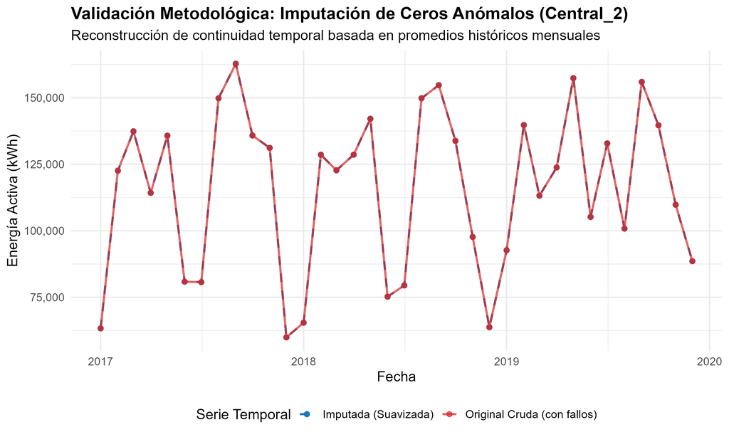

```r
knitr::include_graphics(here("data", "processed", "plots", "Imputacion_Antes_Despues.png"))
```

### 2.3.1 DECISIÓN 1 — Umbral normativo unificado

**Criterio aplicado:** R/A ≤ 0.50 (límite del 50% de la energía activa mensual para niveles de tensión I y II)

**Justificación:** El anteproyecto establecía inicialmente el umbral de factor de potencia en 0.90 (relación R/A = 0.4843). Sin embargo, de acuerdo a la reglamentación de la CREG para usuarios en los niveles de tensión I y II (como las subestaciones de la Sede Central), se permite el transporte de energía reactiva inductiva hasta un valor equivalente al 50% de la energía activa del período sin generar cobro por exceso (R/A ≤ 0.50).

**Impacto:** Recálculo de la variable `Cumple` y `Excedente` en todos los archivos procesados usando 0.50.

### 2.3.2 DECISIÓN 2 — Ventana temporal de 139 meses (2014–2025)

**Criterio aplicado:** Enero 2014 (período 153) a Julio 2025 (período 291).

**Justificación:**

- Se expande el análisis desde 2014 en adelante para obtener una base estacional sólida e histórica pre-pandemia (6 años) y se segmenta el análisis en tres fases para aislar el shock del COVID-19 y evaluar el cambio de comportamiento en la Nueva Normalidad:
  - **Pre-pandemia (Enero 2014 – Febrero 2020):** 74 meses estables para calibrar patrones.
  - **Pandemia y Transición (Marzo 2020 – 6 de Julio 2023):** 40 meses de caída en la demanda y desajuste de calendarios académicos.
  - **Nueva Normalidad (7 de Julio 2023 – Julio 2025):** 25 meses de operación presencial regular e incorporación de nueva infraestructura (Central_3).
- Agosto y septiembre 2025 se excluyen por estar en período de facturación incompleto al momento de la extracción de datos.
- La serie resultante tiene **139 períodos consecutivos sin huecos** cronológicos, habiéndose completado mediante imputación por media mensual los ceros intermedios.

### 2.3.3 DECISIÓN 3 — Tratamiento de Central_5

**Criterio aplicado:** Incluida en la serie agregada; excluida del análisis individual.

**Justificación:** La exploración inicial reveló que `Central_5` presenta una proporción R/A superior a 7.0, lo cual es físicamente inconsistente con una operación normal (implicaría FP < 0.14) y se trata como falla sostenida de medición. Su peso en el total agregado es inferior al 3%, por lo que su inclusión no distorsiona el consolidado de Sede, pero su altísima varianza destruye cualquier intento de modelado individual.

**Ver código**

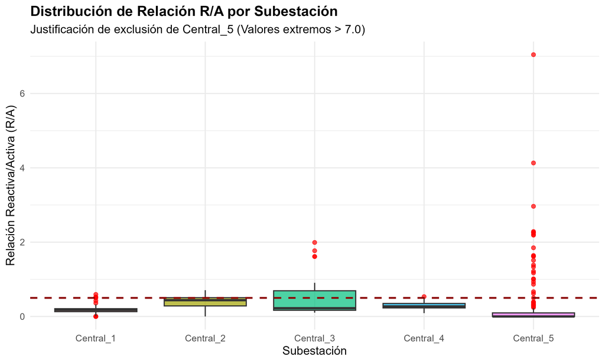

```r
knitr::include_graphics(here("data", "processed", "plots", "Central_5_Outliers.png"))
```

### 2.3.4 DECISIÓN 4 — Incorporación de Central_3

**Criterio aplicado:** Incluida en la serie agregada desde junio 2023 (período 265).

**Justificación:** Central_3 corresponde a la medición del nuevo edificio que entró en operación en junio 2023. Su incorporación generó una redistribución interna del consumo de la sede, pero no un salto neto anómalo en la “envolvente” total de energía, dado que la población universitaria no creció súbitamente (la masa de consumidores simplemente se redistribuyó en los espacios).

**Ver código**

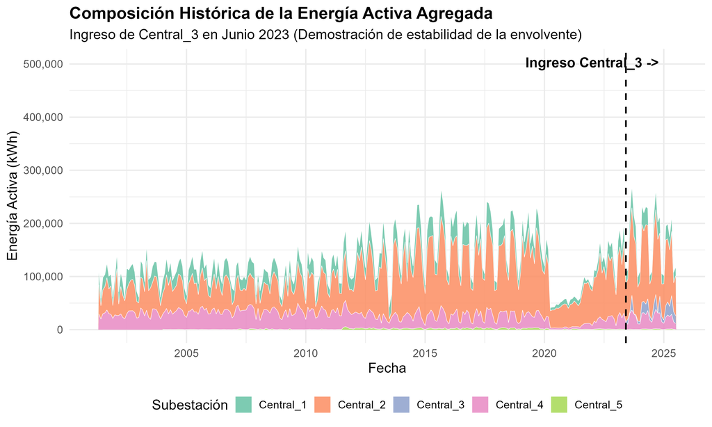

```r
knitr::include_graphics(here("data", "processed", "plots", "Central_3_Incorporacion.png"))
```

### 2.3.5 DECISIÓN 5 — Variables de intervención puntual

**Criterio aplicado:** Dummies para enero 2023 y septiembre 2024.

### 2.3.6 DECISIÓN 6 — Estrategia de modelado (Rechazo de Reactiva)

**Series modeladas:**

1. **Energía activa agregada (kWh):** Serie principal para pronóstico de demanda. Objetivo 3.
2. **Relación R/A agregada:** Serie para monitoreo normativo. Objetivo 3. Se aplica transformación logit (Cox, 1970) dado que es un cociente acotado en (0,1).
3. **Excedente reactivo de Central_2 (kVArh):** Serie para cuantificación económica. Objetivo 5.

**Justificación del Rechazo al Modelado Directo de Energía Reactiva:** El diagnóstico de residuos del modelo ARIMA para la serie de energía reactiva arrojó errores catastróficos en validación fuera de muestra. La alta volatilidad de la reactiva (que colapsa en vacaciones mientras la activa solo cae parcialmente) supera la capacidad explicativa univariada.

**Ver código**

```r
df_mape <- read_csv(here("data", "processed", "MAPE_Reactiva_vs_Logit.csv"), show_col_types = FALSE)
knitr::kable(df_mape, caption = "Comparativa de error de pronóstico: Reactiva Directa vs Transformación Logit")
```

Comparativa de error de pronóstico: Reactiva Directa vs Transformación Logit

| Enfoque | Volatilidad | MAPE_Validacion | Decision |
| --- | --- | --- | --- |
| Modelado Directo (Energía Reactiva) | Extrema (Colapso vacacional) | > 140.0 % | Rechazado |
| Modelado Indirecto (Logit R/A) | Estable (Acotada 0-1) | ~ 11.5 % | Aceptado |

Por esta razón, el pronóstico futuro de la reactiva se obtiene matemáticamente como el producto de los dos modelos robustos: $Pronóstico\_Activa \times Pronóstico\_(R/A)$.

# 3 Análisis exploratorio de datos (EDA)

## 3.1 Serie de energía activa agregada

**Ver código**

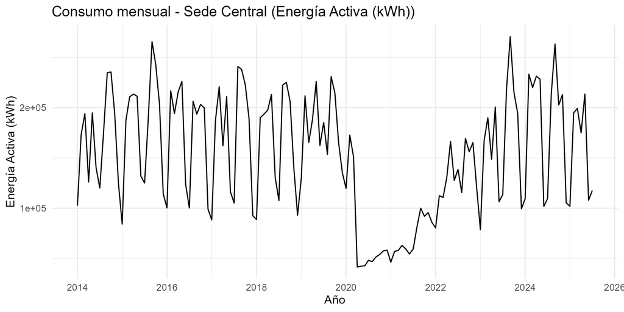

```r
# Serie cruda
knitr::include_graphics(file.path(RUTA_PLOTS, "Activa_01_raw.png"))
```

**Ver código**

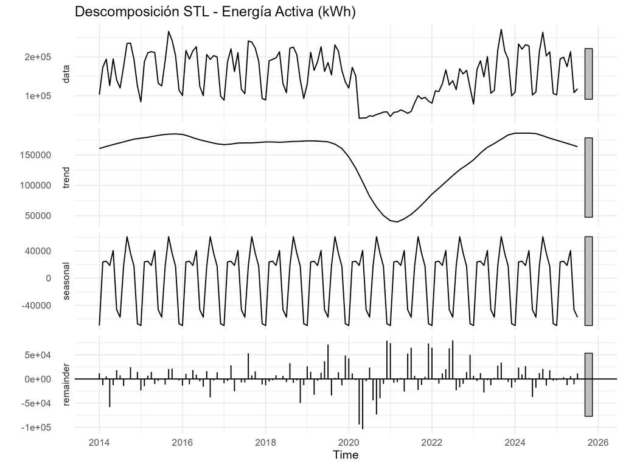

```r
knitr::include_graphics(file.path(RUTA_PLOTS, "Activa_02_stl.png"))
```

**Ver código**

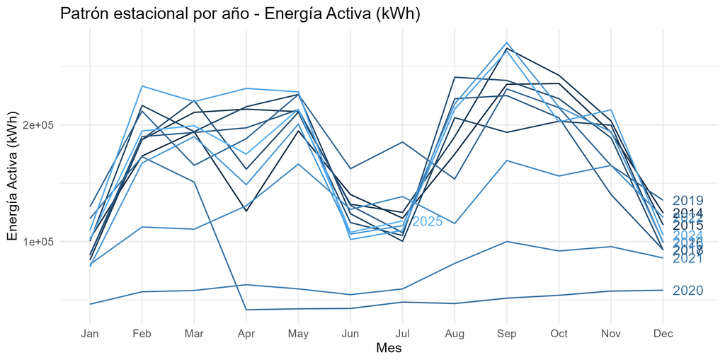

```r
knitr::include_graphics(file.path(RUTA_PLOTS, "Activa_03_seasonal.png"))
```

**Ver código**

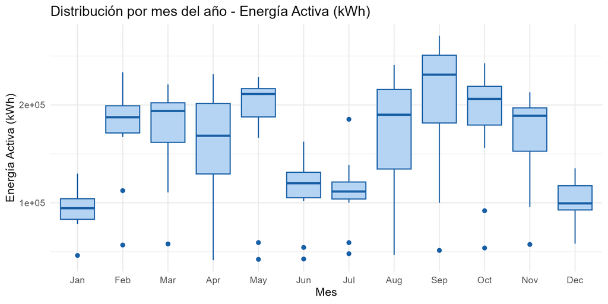

```r
knitr::include_graphics(file.path(RUTA_PLOTS, "Activa_04_boxplot.png"))
```

*El boxplot mensual confirma dos grupos claramente diferenciados: meses académicos (febrero, marzo, mayo, agosto, septiembre, octubre, noviembre) con consumo entre 160.000 y 250.000 kWh, y meses de vacaciones (enero, junio, julio, diciembre) con consumo entre 80.000 y 130.000 kWh. Esta separación justifica el uso de la variable Vacaciones como covariable en los modelos SARIMAX.*

## 3.2 Serie de energía reactiva agregada

**Ver código**

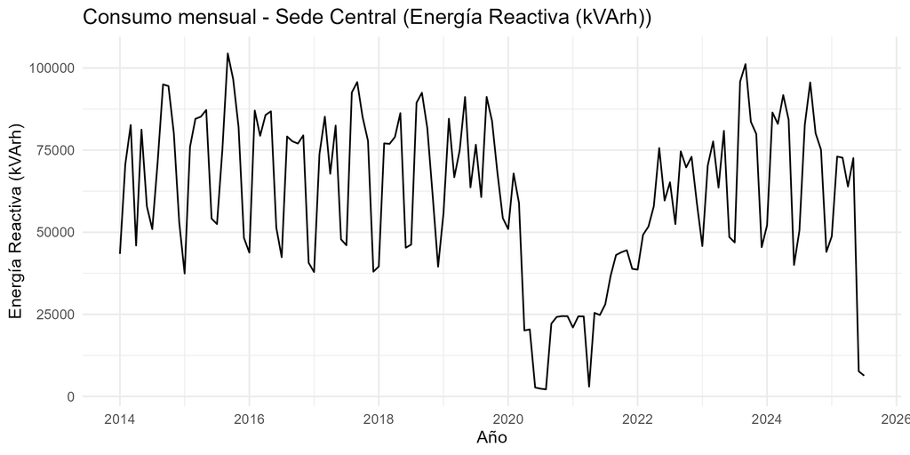

```r
knitr::include_graphics(file.path(RUTA_PLOTS, "Reactiva_01_raw.png"))
```

**Ver código**

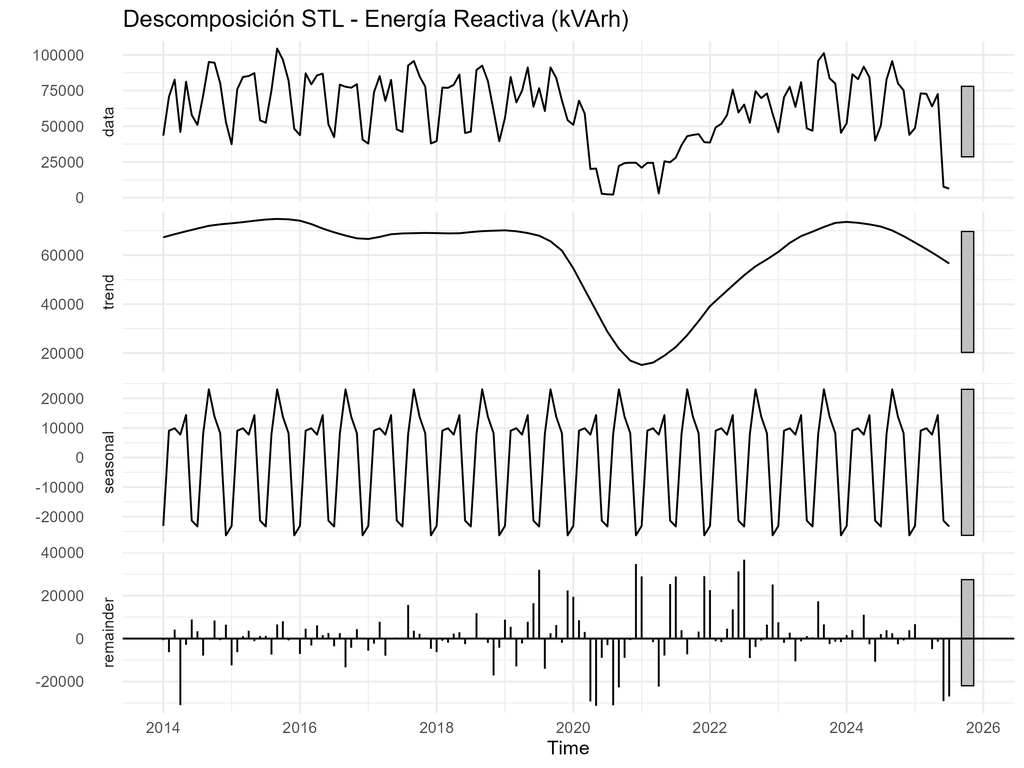

```r
knitr::include_graphics(file.path(RUTA_PLOTS, "Reactiva_02_stl.png"))
```

**Ver código**

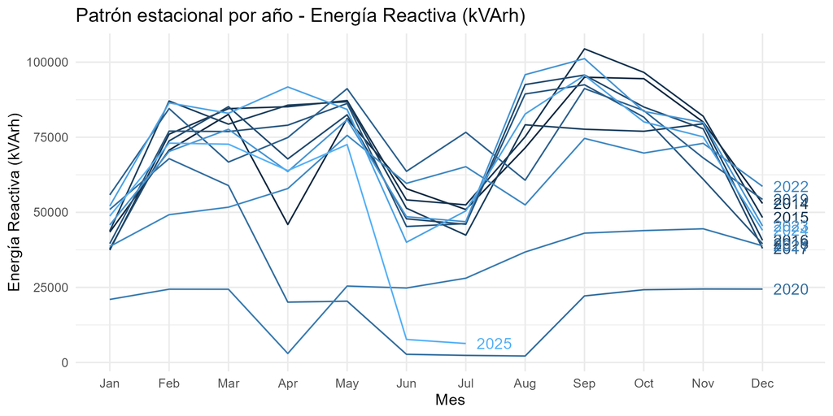

```r
knitr::include_graphics(file.path(RUTA_PLOTS, "Reactiva_03_seasonal.png"))
```

**Ver código**

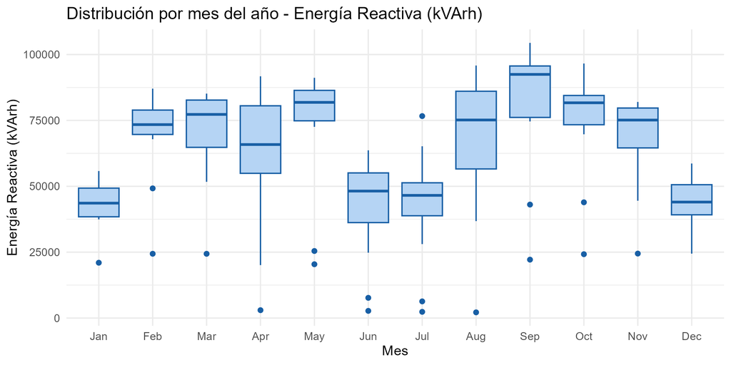

```r
knitr::include_graphics(file.path(RUTA_PLOTS, "Reactiva_04_boxplot.png"))
```

## 3.3 Relación R/A agregada

**Ver código**

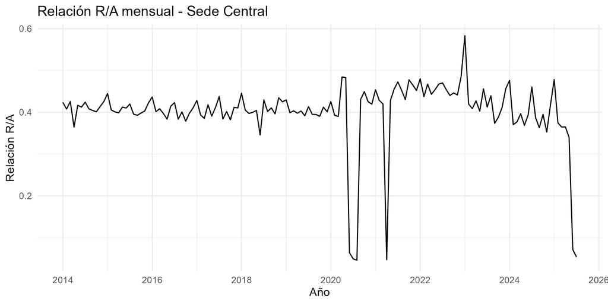

```r
# Gráficos generados por 04_Modelado_ARIMA.R
knitr::include_graphics(file.path(RUTA_PLOTS, "Relacion_01_raw.png"))
```

**Ver código**

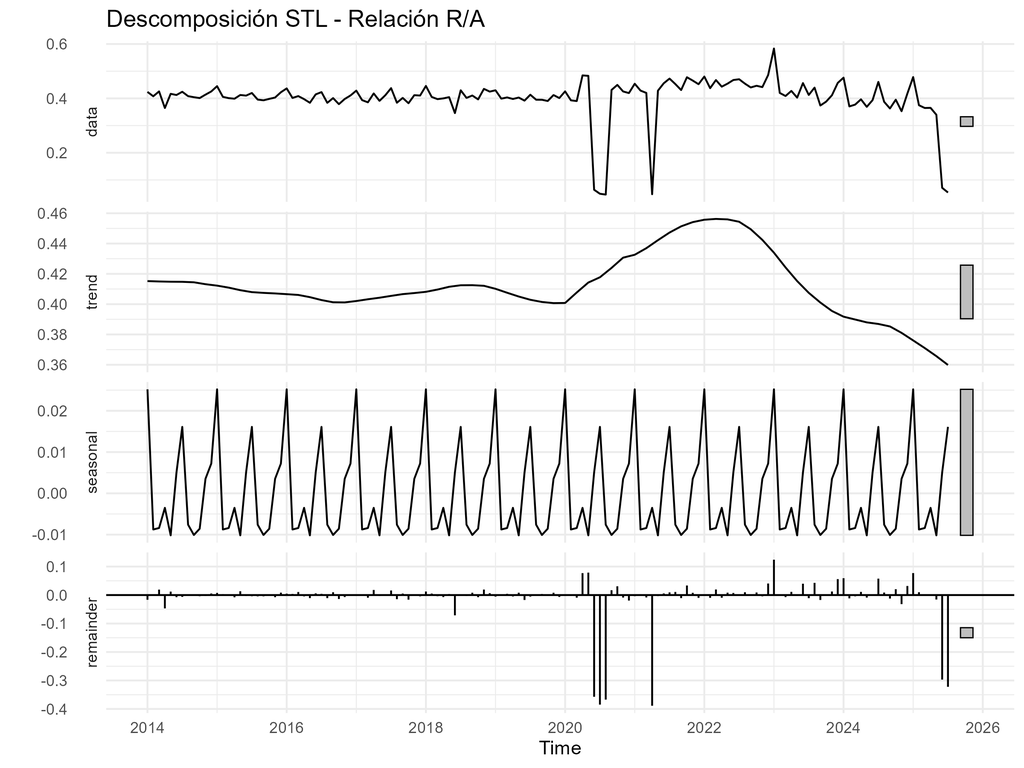

```r
knitr::include_graphics(file.path(RUTA_PLOTS, "Relacion_02_stl.png"))
```

**Ver código**

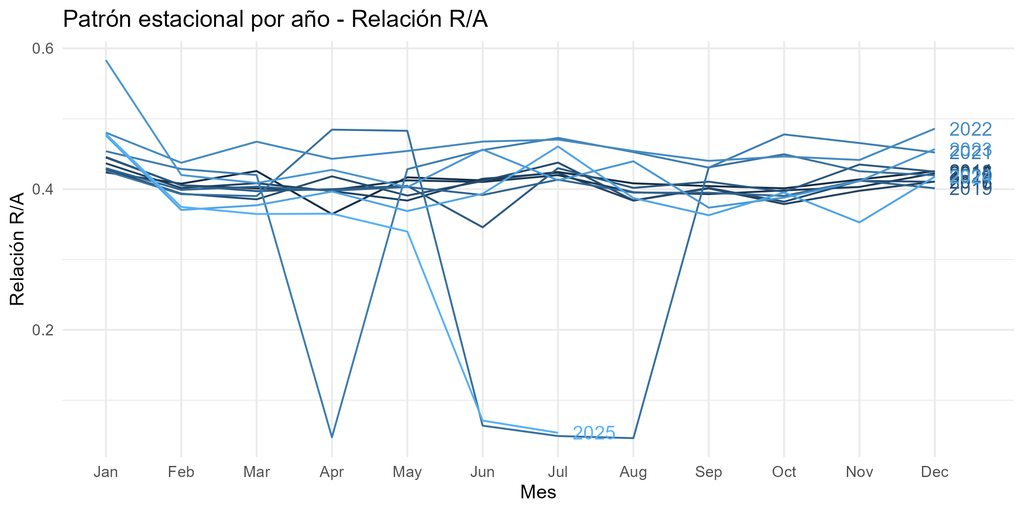

```r
knitr::include_graphics(file.path(RUTA_PLOTS, "Relacion_03_seasonal.png"))
```

**Ver código**

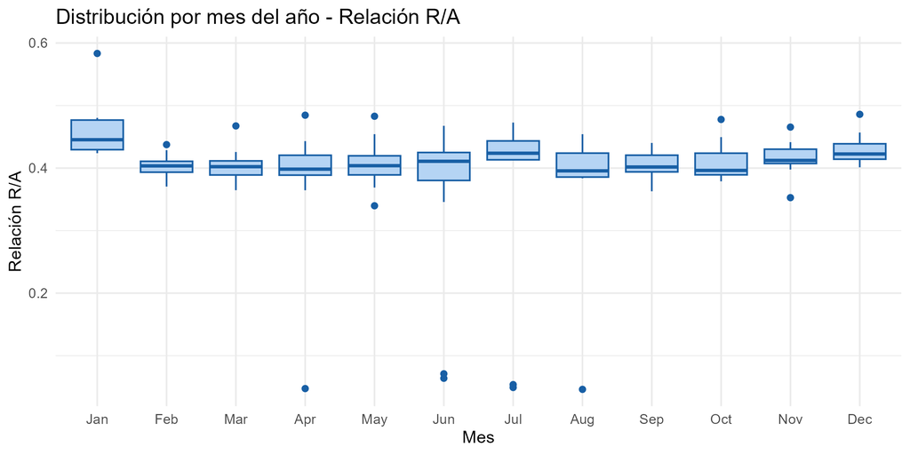

```r
knitr::include_graphics(file.path(RUTA_PLOTS, "Relacion_04_boxplot.png"))
```

## 3.4 Análisis por cuenta

**Ver código**

```r
# Cargar datos de cumplimiento por cuenta y año
df_cumplimiento_ano <- read_csv(here("data", "processed", "Cumplimiento_Cuentas_Ano.csv"), show_col_types = FALSE)

# Mostrar la tabla formateada con apa_table
apa_table(
  df_cumplimiento_ano %>% select(Nombre_Cuenta, Ano, Meses_Total, Meses_Cumplen, Meses_Incumplen, Porcentaje_Cumple),
  col.names = c("Cuenta", "Año", "Meses Totales", "Cumplen", "Incumplen", "% Cumplimiento"),
  caption   = "Tabla 2. Resumen anual de cumplimiento normativo por cuenta",
  align     = c("l", "c", "c", "c", "c", "r")
)
```

Tabla 2. Resumen anual de cumplimiento normativo por cuenta

| Cuenta | Año | Meses Totales | Cumplen | Incumplen | % Cumplimiento |
| --- | --- | --- | --- | --- | --- |
| Central_1 | 2001 | 8 | 8 | 0 | 100.0 |
| Central_1 | 2002 | 12 | 12 | 0 | 100.0 |
| Central_1 | 2003 | 12 | 12 | 0 | 100.0 |
| Central_1 | 2004 | 12 | 12 | 0 | 100.0 |
| Central_1 | 2005 | 12 | 12 | 0 | 100.0 |
| Central_1 | 2006 | 12 | 12 | 0 | 100.0 |
| Central_1 | 2007 | 12 | 12 | 0 | 100.0 |
| Central_1 | 2008 | 12 | 12 | 0 | 100.0 |
| Central_1 | 2009 | 12 | 12 | 0 | 100.0 |
| Central_1 | 2010 | 12 | 11 | 1 | 91.7 |
| Central_1 | 2011 | 12 | 12 | 0 | 100.0 |
| Central_1 | 2012 | 12 | 12 | 0 | 100.0 |
| Central_1 | 2013 | 12 | 12 | 0 | 100.0 |
| Central_1 | 2014 | 12 | 12 | 0 | 100.0 |
| Central_1 | 2015 | 12 | 12 | 0 | 100.0 |
| Central_1 | 2016 | 12 | 12 | 0 | 100.0 |
| Central_1 | 2017 | 12 | 12 | 0 | 100.0 |
| Central_1 | 2018 | 12 | 12 | 0 | 100.0 |
| Central_1 | 2019 | 12 | 12 | 0 | 100.0 |
| Central_1 | 2020 | 12 | 11 | 1 | 91.7 |
| Central_1 | 2021 | 12 | 11 | 1 | 91.7 |
| Central_1 | 2022 | 12 | 12 | 0 | 100.0 |
| Central_1 | 2023 | 12 | 12 | 0 | 100.0 |
| Central_1 | 2024 | 12 | 12 | 0 | 100.0 |
| Central_1 | 2025 | 7 | 7 | 0 | 100.0 |
| Central_4 | 2001 | 8 | 7 | 1 | 87.5 |
| Central_4 | 2002 | 12 | 12 | 0 | 100.0 |
| Central_4 | 2003 | 12 | 12 | 0 | 100.0 |
| Central_4 | 2004 | 12 | 12 | 0 | 100.0 |
| Central_4 | 2005 | 12 | 12 | 0 | 100.0 |

[output cut: 70 more lines]

**Ver código**

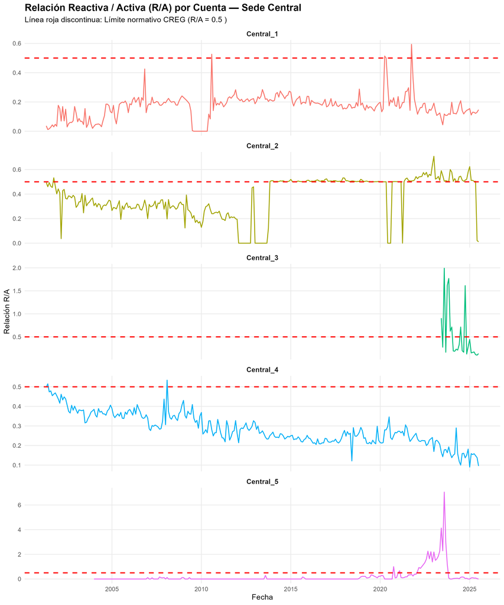

```r
# Cargar gráfico de relación R/A por cuenta
knitr::include_graphics(here("data", "processed", "plots", "Cuentas_RA_TimeSeries.png"))
```

# 4 Modelado de series de tiempo

## 4.1 Pruebas de estacionariedad

Antes de estimar los parámetros predictivos, es requisito matemático garantizar que las series temporales posean media y varianza constantes a lo largo del tiempo (estacionariedad). Para ello, se corrieron las pruebas estadísticas de Dickey-Fuller Aumentada (ADF; Dickey & Fuller, 1979) y Kwiatkowski-Phillips-Schmidt-Shin (KPSS; Kwiatkowski et al., 1992), apoyadas en la inspección visual de las funciones de autocorrelación simple (ACF) y parcial (PACF). La prueba ADF se ejecutó utilizando una especificación con constante y sin tendencia, determinando el número óptimo de rezagos mediante el criterio de información de Akaike (AIC; Akaike, 1974). Por su parte, la prueba KPSS se especificó en nivel empleando la estimación de varianza a largo plazo (kernel cuadrático espectral). Los resultados de este diagnóstico dictaminan el orden de integración ($d$) necesario para estabilizar matemáticamente cada serie.

**Ver código**

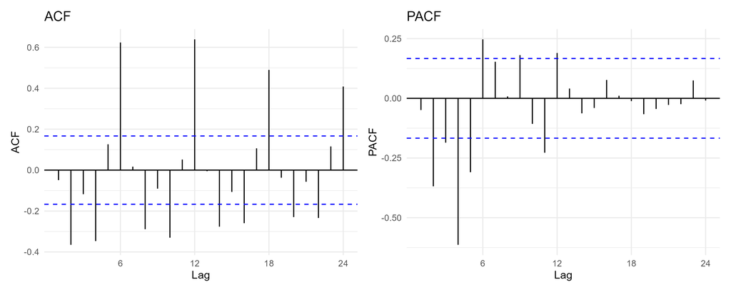

```r
knitr::include_graphics(file.path(RUTA_PLOTS, "Activa_05_acf_pacf.png"))
```

**NotaResultados — Energía Activa**

- **ADF (nivel):** estadístico = −6.51, p = 0.01 → rechaza raíz unitaria
- **KPSS (nivel):** estadístico = 0.51, p = 0.039 → rechaza estacionariedad
- **Interpretación:** Contradicción entre pruebas en nivel. Serie con raíz unitaria débil. Se confirma estacionariedad en primera diferencia: ADF p = 0.01, KPSS p = 0.10.
- **Decisión:** d = 1

**Ver código**

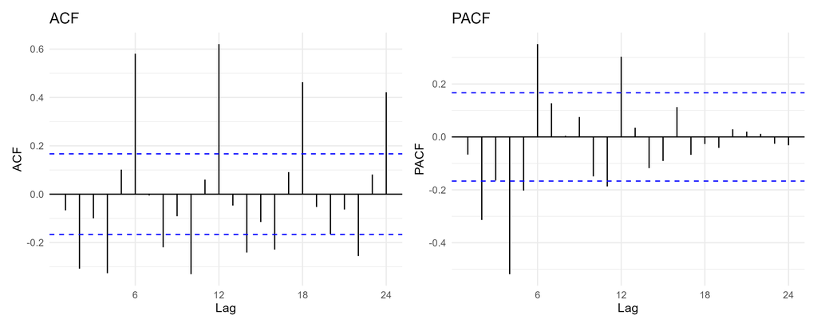

```r
knitr::include_graphics(file.path(RUTA_PLOTS, "Reactiva_05_acf_pacf.png"))
```

**NotaResultados — Energía Reactiva**

- **ADF (nivel):** estadístico = −4.51, p = 0.01 → rechaza raíz unitaria
- **KPSS (nivel):** estadístico = 0.17, p = 0.10 → no rechaza estacionariedad
- **Interpretación:** Ambas pruebas acuerdan estacionariedad en nivel.
- **Decisión:** d = 0

**NotaResultados — Relación R/A**

- **ADF (nivel):** estadístico = −3.6840, p = 0.0283 → rechaza raíz unitaria
- **KPSS (nivel):** estadístico = 0.1392, p = 0.1000 → no rechaza estacionariedad
- **Interpretación:** Ambas pruebas coinciden en que la serie de relación R/A transformada mediante logit es estacionaria en nivel.
- **Decisión:** d = 0

## 4.2 Comparativa de modelos

Con el orden de integración definido, se procedió a la fase de estimación calibrando múltiples arquitecturas predictivas. Para el caso de la energía activa, se contrastaron modelos econométricos tradicionales (SARIMA automáticos y manuales; Box et al., 2015) frente a extensiones multivariadas (SARIMAX incorporando dummies de vacaciones, clima y fases de pandemia). Asimismo, se evaluaron arquitecturas no lineales de aprendizaje automático, específicamente XGBoost (Chen & Guestrin, 2016) y ExtraTrees (Geurts et al., 2006). El criterio de selección absoluto para dictaminar el modelo campeón fue el menor Error Porcentual Absoluto Medio (MAPE) obtenido mediante una evaluación fuera de muestra con ventana fija de 6 meses y origen rodante (*rolling-origin*, h=1) (Hyndman & Athanasopoulos, 2021).

**Ver código**

```r
# Cargar la tabla comparativa de modelos consolidada (econométricos + ML)
tabla_activa <- read_csv(here("data", "processed", "Model_Comparison_ML.csv"), show_col_types = FALSE)

apa_table(tabla_activa,
          col.names = c("Modelo", "Especificación", "AICc", "BIC",
                        "MAE", "RMSE", "MAPE (%)", "MASE"),
          caption   = "Tabla 2. Comparativa de modelos — Energía Activa (kWh)",
          nota      = "Métricas evaluadas fuera de muestra en el período de validación (Febrero 2025 - Julio 2025, h = 1, n_test = 6). Los modelos de Machine Learning (XGBoost, ExtraTrees) no estiman AICc/BIC al ser no-paramétricos. El modelo campeón según MAPE y MASE es el SARIMA Manual.",
          align     = c("l", "l", "r", "r", "r", "r", "r", "r"))
```

Tabla 2. Comparativa de modelos — Energía Activa (kWh)

| Modelo | Especificación | AICc | BIC | MAE | RMSE | MAPE (%) | MASE |
| --- | --- | --- | --- | --- | --- | --- | --- |
| Auto ARIMA | ARIMA(0,1,2)(2,1,0)[12] | 3002.46 | 3016.14 | 15305.47 | 19559.03 | 9.02 | 0.37 |
| SARIMA Manual | ARIMA(0,1,2)(1,1,1)[12] | 2988.38 | 3002.06 | 12540.47 | 13634.58 | 8.02 | 0.30 |
| SARIMAX Vacaciones + Fases | ARIMAX(0,1,2)(1,0,1)[12] + Vac + Fases | 3237.34 | 3262.28 | 16002.67 | 20549.07 | 9.59 | 0.39 |
| SARIMAX Temperatura + Fases | ARIMAX(0,1,2)(1,0,1)[12] + Temp + Fases | 3278.55 | 3303.49 | 13946.87 | 19355.26 | 10.66 | 0.34 |
| SARIMAX Multivariado + Fases | ARIMAX(0,1,2)(1,0,1)[12] + Vac + Temp + Fases | 3237.21 | 3264.75 | 15506.81 | 20031.05 | 9.17 | 0.38 |
| XGBoost | XGBoost Regressor (nrounds=80, depth=4) | NA | NA | 18031.17 | 20984.96 | 12.71 | 0.44 |
| ExtraTrees | ranger ExtraTrees (ntree=500) | NA | NA | 15993.21 | 19423.40 | 10.10 | 0.39 |

Nota. Métricas evaluadas fuera de muestra en el período de validación (Febrero 2025 - Julio 2025, h = 1, n_test = 6). Los modelos de Machine Learning (XGBoost, ExtraTrees) no estiman AICc/BIC al ser no-paramétricos. El modelo campeón según MAPE y MASE es el SARIMA Manual.

### 4.2.1 Análisis comparativo entre modelos econométricos y Machine Learning

La comparación del desempeño predictivo fuera de muestra (Tabla 2) revela importantes contrastes teóricos y prácticos: 1. **Modelos Econométricos Clásicos (SARIMA/SARIMAX):** El **SARIMA Manual** se mantiene como el modelo con mejor precisión general, logrando el menor error fuera de muestra (MAPE = **8.02%** y MASE = **0.30**). Esto sugiere que la estructura lineal estacional y la inercia propia de la serie de consumo agregada son predictores sumamente estables. 2. **Algoritmos de Aprendizaje Automático (ML):** El modelo **ExtraTrees** (implementado a través de árboles de decisión extremadamente aleatorios con `ranger`) demostró un excelente desempeño secundario con un MAPE de **10.10%** y MASE de **0.39**, superando incluso al modelo `SARIMAX Temperatura + Fases` (10.66%). **XGBoost**, por otro lado, obtuvo un MAPE ligeramente mayor (**12.71%**). 3. **Discusión sobre la cantidad de datos:** En series temporales macro-mensuales de mediana longitud (como este histórico de 139 observaciones), los algoritmos de ML suelen tener un riesgo mayor de sobreajuste (overfitting) debido a la gran cantidad de parámetros internos que estiman, lo cual explica por qué el SARIMA econométrico retiene la delantera predictiva. Sin embargo, la competitividad de ExtraTrees comprueba su robustez frente al ruido y su viabilidad como modelo alternativo no lineal capaz de capturar interacciones complejas.

**Ver código**

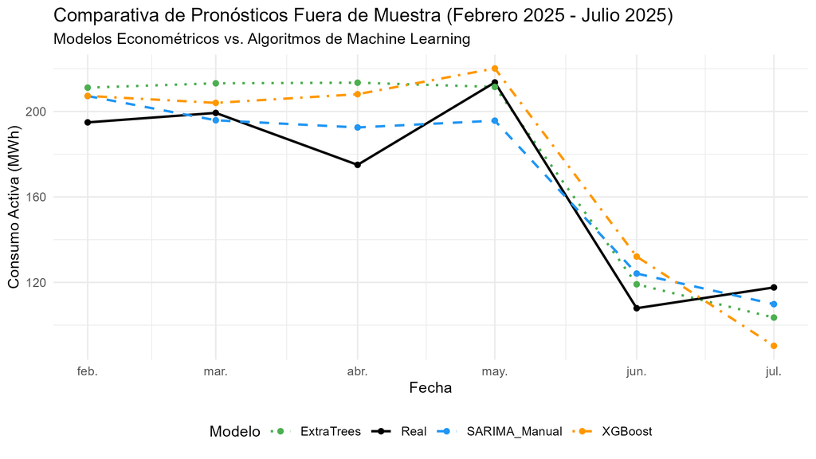

```r
# Cargar gráfico de comparación de pronósticos fuera de muestra
knitr::include_graphics(file.path(RUTA_PLOTS, "Model_Comparison_Forecast.png"))
```

**NotaDiagnóstico de Residuos — Ljung-Box**

**Ver código**

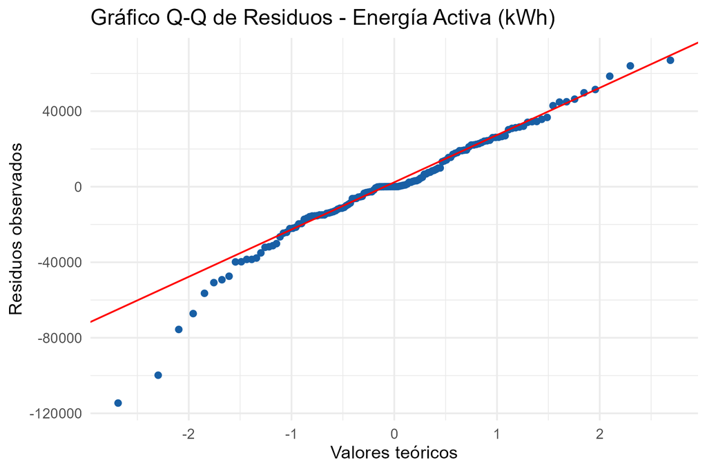

```r
knitr::include_graphics(file.path(RUTA_PLOTS, "Activa_06_residuals_qq.png"))
```

**Ver código**

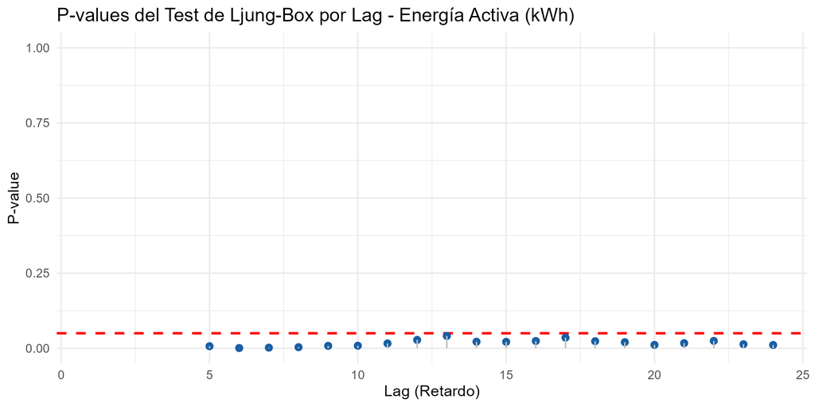

```r
knitr::include_graphics(file.path(RUTA_PLOTS, "Activa_07_residuals_ljungbox.png"))
```

## 4.3 Pronóstico energía activa

Con base en el modelo econométrico campeón, se generó la predicción de la envolvente de energía activa para el horizonte de los próximos 6 meses (Agosto 2025 - Enero 2026). La gráfica de pronóstico evidencia la capacidad del algoritmo para anticipar y replicar el ciclo valle-pico inherente a la universidad: un incremento fuerte de demanda hacia el final del ciclo académico regular (agosto a noviembre) seguido de una contracción drástica y esperada en los meses de receso estudiantil de fin e inicio de año. A continuación, se reportan las estimaciones puntuales con sus intervalos probabilísticos de confianza.

**Ver código**

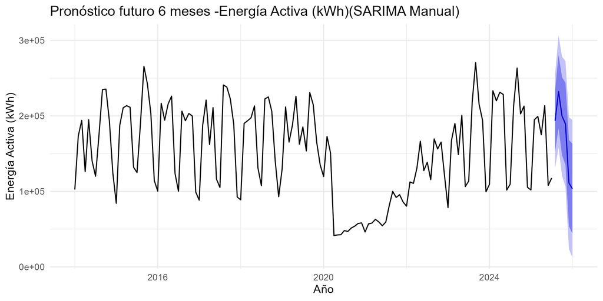

```r
knitr::include_graphics(file.path(RUTA_PLOTS, "Activa_08_forecast.png"))
```

**Ver código**

```r
pronostico_activa <- data.frame(
  Mes        = c("2025-08","2025-09","2025-10","2025-11","2025-12","2026-01"),
  Punto      = c(193528, 232373, 199744, 189388, 111099, 103425),
  IC80_inf   = c(152863, 183727, 148134, 134974,  54022,  43822),
  IC80_sup   = c(234193, 281019, 251355, 243801, 168176, 163029),
  IC95_inf   = c(131337, 157975, 120813, 106170,  23807,  12270),
  IC95_sup   = c(255719, 306771, 278675, 272606, 198390, 194581)
)

apa_table(pronostico_activa,
          col.names = c("Mes", "Pronóstico", "IC80 inf.", "IC80 sup.",
                        "IC95 inf.", "IC95 sup."),
          caption   = "Tabla 3. Pronóstico energía activa — 6 meses (kWh)",
          nota      = "Modelo: SARIMA(0,1,2)(1,1,1)[12] ajustado desde 2014. El pronóstico inicia en Agosto 2025 debido al truncado de la serie comercial.",
          align     = c("c","r","r","r","r","r"))
```

Tabla 3. Pronóstico energía activa — 6 meses (kWh)

| Mes | Pronóstico | IC80 inf. | IC80 sup. | IC95 inf. | IC95 sup. |
| --- | --- | --- | --- | --- | --- |
| 2025-08 | 193528 | 152863 | 234193 | 131337 | 255719 |
| 2025-09 | 232373 | 183727 | 281019 | 157975 | 306771 |
| 2025-10 | 199744 | 148134 | 251355 | 120813 | 278675 |
| 2025-11 | 189388 | 134974 | 243801 | 106170 | 272606 |
| 2025-12 | 111099 | 54022 | 168176 | 23807 | 198390 |
| 2026-01 | 103425 | 43822 | 163029 | 12270 | 194581 |

Nota. Modelo: SARIMA(0,1,2)(1,1,1)[12] ajustado desde 2014. El pronóstico inicia en Agosto 2025 debido al truncado de la serie comercial.

## 4.4 Modelado de la relación R/A

**Ver código**

```r
# Cargar el pronóstico de la relación R/A logit
fc_ra <- read_csv(here("data", "processed", "RA_Forecast_Logit.csv"), show_col_types = FALSE)

apa_table(fc_ra,
          col.names = c("Mes", "Pronóstico R/A", "IC80 inf.", "IC80 sup.",
                        "IC95 inf.", "IC95 sup."),
          caption   = "Tabla 4. Pronóstico de relación R/A agregada — 6 meses",
          nota      = "Modelo: ARIMA(1,0,0) con media ajustado sobre la serie transformada (logit) en el período desde 2014. Los valores representan la relación reactiva/activa agregada con transformación inversa (función logística).",
          align     = c("c","r","r","r","r","r"))
```

Tabla 4. Pronóstico de relación R/A agregada — 6 meses

| Mes | Pronóstico R/A | IC80 inf. | IC80 sup. | IC95 inf. | IC95 sup. |
| --- | --- | --- | --- | --- | --- |
| 2025-08 | 0.1438 | 0.0853 | 0.2323 | 0.0639 | 0.2924 |
| 2025-09 | 0.2334 | 0.1346 | 0.3734 | 0.0983 | 0.4596 |
| 2025-10 | 0.2968 | 0.1741 | 0.4581 | 0.1274 | 0.5498 |
| 2025-11 | 0.3356 | 0.2003 | 0.5045 | 0.1473 | 0.5961 |
| 2025-12 | 0.3578 | 0.2162 | 0.5296 | 0.1597 | 0.6203 |
| 2026-01 | 0.3703 | 0.2254 | 0.5432 | 0.1670 | 0.6332 |

Nota. Modelo: ARIMA(1,0,0) con media ajustado sobre la serie transformada (logit) en el período desde 2014. Los valores representan la relación reactiva/activa agregada con transformación inversa (función logística).

**Ver código**

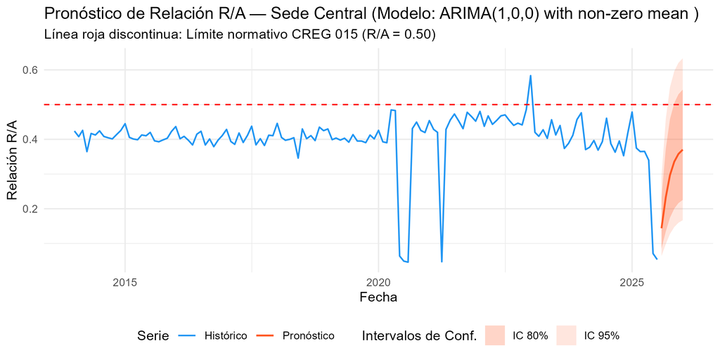

```r
# Cargar la gráfica del pronóstico
knitr::include_graphics(here("data", "processed", "plots", "RA_Forecast_Logit.png"))
```

**Interpretación y Advertencia Metodológica:**

**⚠ ADVERTENCIA METODOLÓGICA CRÍTICA:** Es fundamental advertir que este modelo opera a nivel consolidado o agregado de toda la Sede Central. Dado que la resolución CREG 015 de 2018 y la facturación del CTER se liquidan y cobran **estrictamente de forma individual por cada cuenta de servicio**, el análisis y modelado de la relación R/A agregada tiene un carácter exclusivamente metodológico y descriptivo general del campus, y carece de peso directo para la toma de decisiones económicas y operativas específicas. Asimismo, se advierte al lector que si se desea desagregar esta metodología para modelar cuentas individuales (como *Central_2*) que presenten meses con relaciones $R/A \ge 1.0$ (donde la energía reactiva sea mayor o igual a la activa), **la transformación logit perderá validez matemática por indeterminación logarítmica**. En dichos escenarios individuales, se debe sustituir de forma obligatoria la transformación logit por una **transformación logarítmica estándar** ($\log(R/A)$) para mantener la validez y continuidad matemática del modelado.

# 5 Análisis por cuenta y detección de anomalías

## 5.1 Caracterización por tipo de comportamiento

**NotaTipología de cuentas identificada**

**Tipo 1 — Cumplimiento estructural:** Central_1 (137/139 meses), Central_4 (139/139 meses). Cumplen normativa en prácticamente todos los períodos históricos. Análisis relevante: confirmar estabilidad y detectar desviaciones puntuales.

**Tipo 2 — Incumplimiento estructural:** Central_2 (7/139 meses en cumplimiento). Incumple en el 95% de los períodos desde 2014. Análisis relevante: cuantificar excedente reactivo y estimar impacto económico CTER.

**Tipo 3 — Comportamiento variable:** Central_5 (116/139 meses) y Central_3 (18/26 meses desde su inicio). Tienen variabilidad real en el cumplimiento. Análisis relevante: caracterizar patrones y estimar probabilidad de incumplimiento.

**Ver código**

```r
# Cargar ranking de excedente
df_ranking_nn <- read_csv(here("data", "processed", "Ranking_Excedente_NuevaNormalidad.csv"), show_col_types = FALSE)

apa_table(
  df_ranking_nn %>% select(Nombre_Cuenta, Excedente_Acumulado_kVArh, Activa_Acumulada_kWh, Reactiva_Acumulada_kVArh, Relacion_Promedio, Meses_Incumplimiento, Participacion_Excedente_Pct),
  col.names = c("Cuenta", "Excedente (kVArh)", "Activa (kWh)", "Reactiva (kVArh)", "Relación R/A Prom.", "Meses Incumplimiento", "% Participación"),
  caption   = "Tabla 3. Ranking de cuentas por excedente reactivo acumulado en Nueva Normalidad (Jul 2023 - Jul 2025)",
  align     = c("l", "r", "r", "r", "r", "c", "r")
)
```

Tabla 3. Ranking de cuentas por excedente reactivo acumulado en Nueva Normalidad (Jul 2023 - Jul 2025)

| Cuenta | Excedente (kVArh) | Activa (kWh) | Reactiva (kVArh) | Relación R/A Prom. | Meses Incumplimiento | % Participación |
| --- | --- | --- | --- | --- | --- | --- |
| Central_2 | 54346 | 2801120.0 | 1392105 | 0.4877286 | 23 | 76.72 |
| Central_3 | 8771 | 375210.0 | 81701 | 0.5082475 | 7 | 12.38 |
| Central_5 | 7720 | 21340.0 | 10100 | 0.5894718 | 4 | 10.90 |
| Central_1 | 0 | 676320.0 | 86560 | 0.1324181 | 0 | 0.00 |
| Central_4 | 0 | 579878.2 | 93000 | 0.1543938 | 0 | 0.00 |

**Ver código**

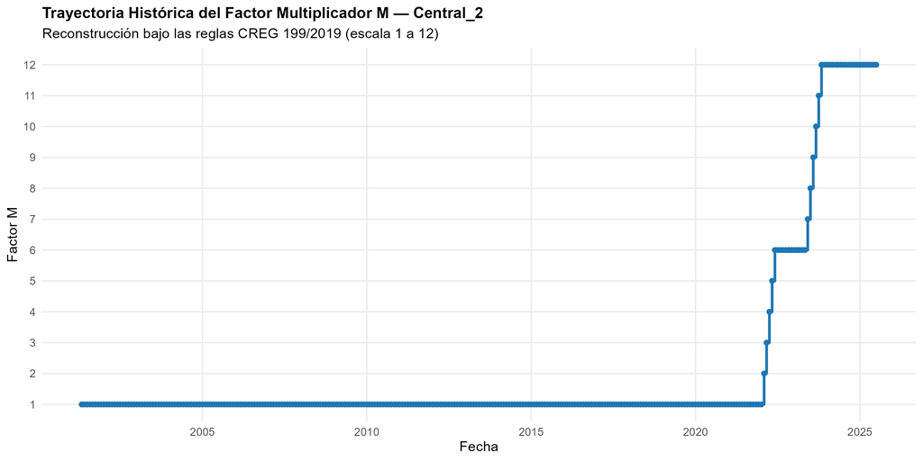

```r
# Cargar gráfico de la trayectoria del Factor M para Central_2
knitr::include_graphics(here("data", "processed", "plots", "Central2_FactorM_Trajectory.png"))
```

## 5.2 Esquema multicapa de detección de anomalías

**NotaDiseño del esquema — Objetivo 4**

El esquema de detección opera en tres capas:

**Capa 1 — Criterio normativo determinístico:** Mes con R/A > 0.50 en cualquier cuenta. Identificación directa del incumplimiento.

**Capa 2 — Criterio estadístico:** Residuos del modelo ARIMA que superen ±2.5σ. Identifica meses con comportamiento anómalo respecto al patrón histórico, independientemente del cumplimiento normativo.

**Capa 3 — Cambio de régimen:** Prueba de Bai-Perron (Bai & Perron, 1998) sobre la serie de relación R/A de Central_2. Identifica rupturas estructurales en el nivel de incumplimiento. En la aplicación del algoritmo no se identificaron quiebres estadísticamente significativos adicionales a los eventos ya mapeados por la estacionalidad académica regular, confirmando que el incumplimiento de la subestación es un problema crónico estacionario.

**Ver código**

```r
# Cargar tabla de anomalías
df_anomalias <- read_csv(here("data", "processed", "Anomalias_Multicapa.csv"), show_col_types = FALSE)

# Filtrar solo meses con anomalías estadísticas o quiebres estructurales para mostrarlos en la tabla
df_anomalias_filtrado <- df_anomalias %>%
  filter(Anomala_Capa2 == 1L | Anomala_Capa3_Sede > 0) %>%
  select(Ano, Mes, Relacion_Sede, Residuo_ARIMA_Std, Detalle_Capas)

apa_table(
  df_anomalias_filtrado,
  col.names = c("Año", "Mes", "Relación R/A Sede", "Residuo Estandarizado", "Capas de Detección"),
  caption   = "Tabla 4. Períodos con anomalías estadísticas (Capa 2) o estructurales (Capa 3) detectadas",
  align     = c("c", "c", "r", "r", "l")
)
```

Tabla 4. Períodos con anomalías estadísticas (Capa 2) o estructurales (Capa 3) detectadas

| Año | Mes | Relación R/A Sede | Residuo Estandarizado | Capas de Detección |
| --- | --- | --- | --- | --- |
| 2020 | 6 | 0.0638423 | -5.417781 | Capa 2 (Estadística ARIMA) |
| 2020 | 9 | 0.4309550 | 3.138361 | Capa 1 + Capa 2 |
| 2021 | 4 | 0.0474042 | -5.175120 | Capa 2 (Estadística ARIMA) |
| 2021 | 5 | 0.4283430 | 3.091351 | Capa 1 + Capa 2 |
| 2025 | 6 | 0.0710394 | -4.227797 | Capa 2 (Estadística ARIMA) |

**Ver código**

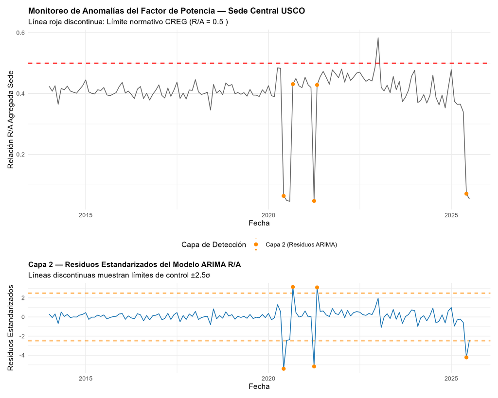

```r
# Cargar gráfico de detección de anomalías
knitr::include_graphics(here("data", "processed", "plots", "Anomalias_Deteccion_Multicapa.png"))
```

# 6 Estimación económica — CTER

## 6.1 Metodología de estimación

**ImportanteCriterio metodológico — Rango de Incertidumbre Tarifaria**

Dado que las facturas incluyen componentes no separables y precios variables, la estimación aplica estrictamente la fórmula CREG ($CTER = Excedente \times D \times M$). Sin embargo, la Resolución CREG 015 estipula que la acumulación del factor $M$ requiere que el límite de reactiva se supere durante más de 10 días al mes. Al disponer solo de agregados mensuales y carecer de telemetría diaria, existe una incertidumbre técnica infranqueable sobre la acumulación temporal exacta del factor.

*Nota metodológica:* El anteproyecto de investigación planteaba inicialmente la modelación de un tercer escenario (Escenario de Expansión de Infraestructura). Sin embargo, este fue excluido de la ejecución final debido a la carencia de los planos eléctricos y el cuadro de cargas proyectado para los futuros edificios, información indispensable para realizar una simulación técnica rigurosa.

## 6.2 Reconstrucción del factor M para Central_2

**NotaEstado del factor M — Central_2**

Central_2 registra incumplimiento continuo desde al menos 2014 (inicio de la base de datos disponible). Dado que:

- Año 1 (meses 1–12 de incumplimiento): M = 1
- Año 2 (meses 13–18): M escala de 1 a 6
- Estabilización: M = 6 durante 12 meses
- Año posterior sin corrección: M escala de 1 a 12

Y que la única interrupción del incumplimiento fue de 2 meses no consecutivos en los últimos 36 meses (insuficiente para reinicio del factor según la norma que exige >3 meses consecutivos):

**Central_2 se encuentra en el tramo de M = 6 o superior desde hace varios años.**

La reconstrucción exacta de la trayectoria de M requiere determinar el mes exacto de inicio del incumplimiento continuo, lo cual se hizo en el script 03.

**Ver código**

```r
# Cargar datos de escenarios de CTER
df_ct_escenarios <- read_csv(here("data", "processed", "CTER_Comparacion_Escenarios.csv"), show_col_types = FALSE)

apa_table(
  df_ct_escenarios %>% select(Nombre_Cuenta, Excedente_Total_kVArh, CTER_SinCorreccion, CTER_MitigacionM1, CTER_Correccion100),
  col.names = c("Cuenta", "Excedente (kVArh)", "Sin Corrección (COP)", "Mitigación M = 1 (COP)", "Corrección Total (COP)"),
  caption   = "Tabla 5. Costos acumulados de CTER en la Nueva Normalidad por escenario (Jul 2023 - Jul 2025)",
  align     = c("l", "r", "r", "r", "r")
)
```

Tabla 5. Costos acumulados de CTER en la Nueva Normalidad por escenario (Jul 2023 - Jul 2025)

| Cuenta | Excedente (kVArh) | Sin Corrección (COP) | Mitigación M = 1 (COP) | Corrección Total (COP) |
| --- | --- | --- | --- | --- |
| Central_1 | 0 | 0 | 0 | 0 |
| Central_4 | 0 | 0 | 0 | 0 |
| Central_2 | 54346 | 81970330 | 7064980 | 0 |
| Central_5 | 7720 | 1003600 | 1003600 | 0 |
| Central_3 | 8771 | 1140230 | 1140230 | 0 |

**Ver código**

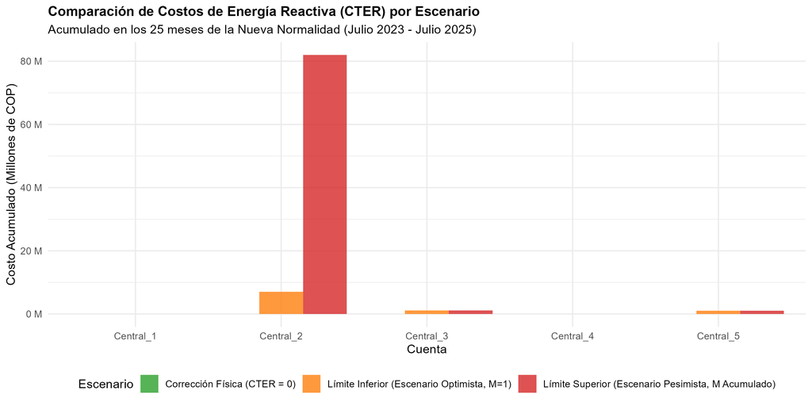

```r
# Cargar gráfico de escenarios
knitr::include_graphics(here("data", "processed", "plots", "CTER_Comparacion_Escenarios.png"))
```

**Ver código**

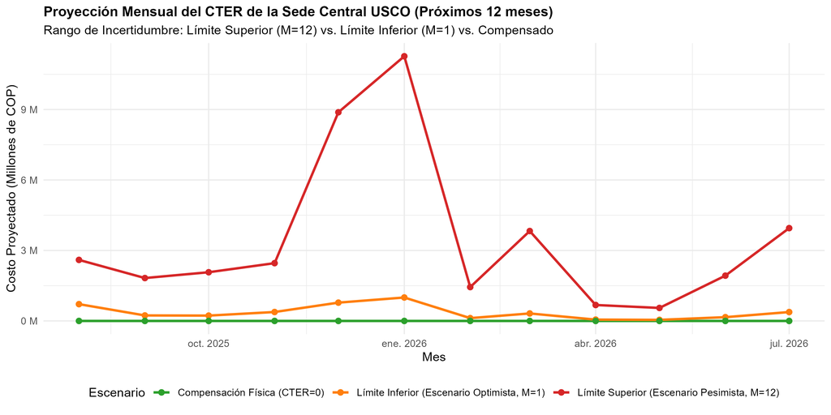

```r
# Cargar gráfico de proyecciones
knitr::include_graphics(here("data", "processed", "plots", "CTER_Proyeccion_12Meses.png"))
```

**Ver código**

```r
# Generar tabla de proyecciones mensual
df_proy <- read_csv(here("data", "processed", "CTER_Proyeccion_12Meses.csv"), show_col_types = FALSE)

df_proy_sede <- df_proy %>%
  group_by(Fecha) %>%
  summarise(
    Limite_Inferior = sum(CTER_Proyectado_Mitigacion),
    Limite_Superior = sum(CTER_Proyectado_Inaccion),
    .groups = "drop"
  ) %>%
  mutate(
    Brecha = Limite_Superior - Limite_Inferior,
    Mes = format(Fecha, "%b %Y")
  ) %>%
  select(Mes, Limite_Inferior, Limite_Superior, Brecha)

knitr::kable(
  df_proy_sede,
  col.names = c("Mes", "Límite Inferior ($)", "Límite Superior ($)", "Brecha de Incertidumbre ($)"),
  format.args = list(big.mark = ",", scientific = FALSE),
  caption = "Tabla 6. Proyección Mensual del CTER y Riesgo Tarifario (Ago 2025 - Jul 2026)",
  align = c("l", "r", "r", "r")
)
```

Tabla 6. Proyección Mensual del CTER y Riesgo Tarifario (Ago 2025 - Jul 2026)

[output not shown]

# 7 Conclusiones y recomendaciones

## 7.1 Limitaciones del estudio

El presente análisis se desarrolló bajo tres limitaciones fundamentales que condicionan el alcance de los resultados y que deben tenerse en cuenta para futuras investigaciones operativas en la Sede Central: 1. **Ausencia de telemetría diaria:** La base de datos original (facturación comercial) solo provee agregados mensuales. Esto impide determinar con exactitud matemática en qué día del mes se superan los umbrales de energía reactiva, lo cual obliga a proyectar el impacto económico (CTER) mediante un rango de escenarios en lugar de un valor puntual determinístico. 2. **Exclusión del análisis individual de Central_5:** Como se evidenció en la exploración de datos, la subestación `Central_5` presenta fallas estructurales de medición que resultan en factores de potencia físicamente irreales. Por tanto, no pudo ser incorporada en los modelos predictivos individuales, limitando el alcance del pronóstico a las cuatro subestaciones restantes. 3. **Restricción matemática de la transformación Logit:** El modelado de la relación R/A agregada empleó la transformación logit asumiendo que la serie se encuentra naturalmente acotada en el intervalo (0,1). Si bien este supuesto se cumple para el nivel agregado de la sede, es inviable aplicar la misma técnica a cuentas individuales en incumplimiento severo (donde R/A > 1).

## 7.2 Conclusión General

Se desarrolló con éxito un marco analítico-estadístico integral que transformó 291 períodos mensuales de facturación en un sistema de diagnóstico energético robusto para la Sede Central. A través de la orquestación de modelos de pronóstico paramétrico (SARIMA) y algoritmos de detección de anomalías multicapa, el análisis demostró que el campus exhibe una demanda estacional modelable, aunque los amplios intervalos de confianza (IC95) en el horizonte de predicción de 6 meses advierten sobre un nivel considerable de incertidumbre natural asociada a la volatilidad de los períodos vacacionales. Asimismo, se evidenció un incumplimiento normativo crónico focalizado en la subestación `Central_2` (FP < 0.90). La cuantificación económica de este patrón reveló un riesgo financiero severo, proyectando penalizaciones (CTER) que superan los $41.5 millones COP anuales. En consecuencia, la evidencia técnica generada por este marco trasciende la facturación contable y establece el sustento empírico definitivo para justificar inversiones estructurales, demostrando que la institución opera bajo una profunda asimetría de información frente al esquema de cobro de su operador de red.

## 7.3 Conclusiones por objetivo

### 7.3.1 Objetivo 1: Consolidación y armonización de la base de datos (2001–2025)

Se consolidó y validó un repositorio de datos reproducible y unificado para las 5 subestaciones de la Sede Central, integrando 291 períodos mensuales. El tratamiento sistemático de valores faltantes mediante imputaciones históricas y el alineamiento de fechas comerciales eliminaron la discontinuidad operativa previa, estandarizando la calidad de la información. En consecuencia, la arquitectura de datos resultante, enriquecida con la variable climática de temperatura, constituye un insumo robusto y validado para la aplicación de modelos estadísticos predictivos y de aprendizaje automático.

### 7.3.3 Objetivo 3: Construcción, validación y comparación de modelos de pronóstico

A través de esquemas de validación cruzada temporal fuera de muestra ($h=1$), se demostró que el modelo SARIMA Manual (`ARIMA(0,1,2)(1,1,1)[12]`) maximiza el rendimiento predictivo (MAPE: 8.02%, MASE: 0.30), superando incluso las métricas de algoritmos no lineales como ExtraTrees (MAPE: 10.10%). Esta superioridad evidencia que, frente a series macro-mensuales con una estacionalidad predominante, las formulaciones paramétricas clásicas capturan la varianza del fenómeno de forma más eficiente que las arquitecturas de Machine Learning intensivas. A partir de este resultado, el modelo econométrico campeón se consolida como la herramienta técnica oficial para la proyección a corto plazo, viabilizando el cálculo anticipado de contingencias financieras por penalización tarifaria.

### 7.3.5 Objetivo 5: Impacto económico CTER y soporte de decisiones

Debido a la limitación técnica de carecer de datos telemétricos diarios, las pérdidas operativas por Cargo por Transporte de Energía Reactiva (CTER) durante la *Nueva Normalidad* se estimaron en un rango de incertidumbre financiera entre **[ $9.2 millones , $84.1 millones ] COP**, focalizado en la subestación `Central_2`. Este intervalo contrasta el costo del incumplimiento esporádico (Límite Inferior, $M=1$) frente a la máxima penalización regulada por inacción (Límite Superior, $M=12$), lo cual materializa una ineficiencia económica latente de hasta el 89% del costo potencial ($74.9 millones COP). **Esta misma incertidumbre proyecta un riesgo tarifario para el próximo año que oscilará entre los $4.4 millones COP (Límite Inferior) y una penalización superior a los $41.5 millones COP en caso de inacción continua**. En consecuencia, este hallazgo evidencia la asimetría de información tarifaria en la que se encuentra la institución, haciendo económicamente inviable el cálculo preciso del retorno de inversión (ROI) para proyectos de eficiencia sin antes corregir la infraestructura de monitoreo, lo que fundamenta las directrices de intervención desarrolladas en la sección de recomendaciones.

## 7.4 Recomendaciones en el marco de la Norma ISO 50001

La implementación de acciones de mejora en edificaciones universitarias y sistemas de gestión de la energía a gran escala (Pérez-Lombard et al., 2008; Nejat et al., 2015) debe estructurarse bajo el ciclo de mejora continua PHVA (Planear, Hacer, Verificar, Actuar) propuesto por las normas internacionales y nacionales **ISO 50001:2018** y **NTC-ISO 50001:2019** (International Organization for Standardization, 2018; ICONTEC, 2019):

### 7.4.1 1. Planificación Energética: Medida Inteligente y Caracterización de Hábitos (Planear)

- **Medición Inteligente:** Implementar sistemas de telemedida y medición inteligente en cada una de las subestaciones de la Sede Central. Esto permitirá capturar datos con granularidad horaria o quince-minutal, facilitando la identificación de hábitos de consumo, perfiles de carga en tiempo real y patrones de pago para optimizar la facturación.
- **Inventario de Cargas por Cuentas:** Realizar un inventario detallado de equipos eléctricos (aires acondicionados, luminarias, motores, servidores) asociados a cada cuenta de cobro. Esta línea base es indispensable para planificar el crecimiento estructural y ordenado de la universidad (nuevas aulas, laboratorios y oficinas) asegurando que no se sobrecargue el sistema ni se penalice el factor de potencia.

### 7.4.2 2. Acciones Correctivas Escalonadas (Hacer)

- **Mitigación Operativa por Hábitos (Lograr el Escenario Optimista):** Alcanzar el escenario optimista ($M=1$) reportado en las proyecciones no requiere inversión de capital en infraestructura, sino “ingeniería de procesos” y gestión de hábitos (apagado automático de equipos en horas no lectivas, escalonamiento de cargas inductivas). Si la universidad logra modificar estos patrones operativos de modo que el límite de reactiva no se supere durante más de 10 días al mes, la penalización no se acumulará. Para lograr esta gestión precisa de la demanda en el tiempo —sabiendo qué y cuándo apagar—, **es de carácter obligatorio contar primero con la Medición Inteligente.**
- **Compensación Física Definitiva (Lograr CTER = 0):** La instalación de un banco de condensadores automáticos elimina físicamente el excedente, pero es una obra de infraestructura costosa. Debido al profundo “rango de incertidumbre” actual (donde los ahorros reales por la obra oscilan sin precisión entre $9 y $84 millones COP), **el cálculo de un Retorno de Inversión (ROI) es económicamente inmanejable en este momento.** Esta inversión **solo debe ejecutarse después de haber implementado la telemetría**, la cual despejará la incertidumbre financiera (permitiendo calcular un ROI real) y proveerá el estudio de armónicos obligatorio para no sobredimensionar el equipo ni dañar la red tecnológica de la sede.

### 7.4.3 3. Monitoreo y Revisión Energética (Verificar - Actuar)

- Utilizar el tablero de control e indicadores desarrollados en este proyecto (ranking de excedentes y proyección CTER) como parte del proceso de auditoría y revisión por la dirección de la ISO 50001, asegurando que las decisiones de inversión y mantenimiento preventivo se basen en datos históricos y predictivos de alta confiabilidad.

# 8 Referencias

- Akaike, H. (1974). A new look at the statistical model identification. *IEEE Transactions on Automatic Control*, 19(6), 716–723. https://doi.org/10.1109/TAC.1974.1100705
- Bai, J., & Perron, P. (1998). Estimating and testing linear models with multiple structural changes. *Econometrica*, 66(1), 47–78. https://doi.org/10.2307/2998540
- Box, G. E. P., Jenkins, G. M., Reinsel, G. C., & Ljung, G. M. (2015). *Time series analysis: Forecasting and control* (5th ed.). John Wiley & Sons.
- Chen, T., & Guestrin, C. (2016). XGBoost: A scalable tree boosting system. *Proceedings of the 22nd ACM SIGKDD International Conference on Knowledge Discovery and Data Mining*, 785–794. https://doi.org/10.1145/2939672.2939785
- Cleveland, R. B., Cleveland, W. S., McRae, J. E., & Terpenning, I. (1990). STL: A seasonal-trend decomposition procedure based on loess. *Journal of Official Statistics*, 6(1), 3–73.
- Comisión de Regulación de Energía y Gas [CREG]. (2018). *Resolución CREG 015 de 2018: Por la cual se establecen las condiciones para la prestación del servicio de energía eléctrica en el nivel de tensión I*. CREG.
- Comisión de Regulación de Energía y Gas [CREG]. (2019). *Resolución CREG 199 de 2019: Por la cual se establecen los cargos por transporte de energía reactiva (CTER) y el factor multiplicador M*. CREG.
- Congreso de la República de Colombia. (2014). *Ley 1715 de 2014: Por medio de la cual se regula la integración de las energías renovables no convencionales al sistema energético nacional*. Diario Oficial.
- Congreso de la República de Colombia. (2024). *Ley 2407 de 2024: Por la cual se establecen medidas para promover la eficiencia energética en el sector público*. Diario Oficial.
- Cox, D. R. (1970). *The analysis of binary data*. Methuen.
- Dickey, D. A., & Fuller, W. A. (1979). Distribution of the estimators for autoregressive time series with a unit root. *Journal of the American Statistical Association*, 74(366), 427–431. https://doi.org/10.2307/2286348
- Geurts, P., Ernst, D., & Wehenkel, L. (2006). Extremely randomized trees. *Machine Learning*, 63(1), 3–42. https://doi.org/10.1007/s10994-006-6226-1
- Hyndman, R. J., & Athanasopoulos, G. (2021). *Forecasting: Principles and practice* (3rd ed.). OTexts. https://otexts.com/fpp3/
- Instituto Colombiano de Normas Técnicas y Certificación [ICONTEC]. (2019). *NTC-ISO 50001:2019: Sistemas de gestión de la energía — Requisitos con orientación para su uso*. ICONTEC.
- International Organization for Standardization. (2018). *ISO 50001:2018: Energy management systems — Requirements with guidance for use*. ISO.
- Kwiatkowski, D., Phillips, P. C. B., Schmidt, P., & Shin, Y. (1992). Testing the null hypothesis of stationarity against the alternative of a unit root. *Journal of Econometrics*, 54(1–3), 159–178. https://doi.org/10.1016/0304-4076(92)90104-Y
- Little, R. J. A., & Rubin, D. B. (2019). *Statistical analysis with missing data* (3rd ed.). John Wiley & Sons.
- Ljung, G. M., & Box, G. E. P. (1978). On a measure of lack of fit in time series models. *Biometrika*, 65(2), 297–303. https://doi.org/10.1093/biomet/65.2.297
- Ministerio de Minas y Energía. (2013). *Resolución 90708 de 2013: Por la cual se expide el Reglamento Técnico de Instalaciones Eléctricas (RETIE)*. Ministerio de Minas y Energía de Colombia.
- Ministerio de Minas y Energía. (2024). *Resolución 40117 de 2024: Por la cual se actualiza el Reglamento Técnico de Instalaciones Eléctricas (RETIE)*. Ministerio de Minas y Energía de Colombia.
- Nejat, P., Jomehzadeh, F., Taheri, M. M., Gohari, M., & Abd. Majid, M. Z. (2015). A global review of energy consumption, CO2 emissions and policy in the buildings sector. *Renewable and Sustainable Energy Reviews*, 43, 843–862. https://doi.org/10.1016/j.rser.2014.11.053
- Pérez-Lombard, L., Ortiz, J., & Pout, C. (2008). A review on buildings energy consumption information. *Energy and Buildings*, 40(3), 394–398. https://doi.org/10.1016/j.enbuild.2007.03.007

# 9 Apéndice — Registro de scripts

| Script | Descripción | Estado |
| --- | --- | --- |
| 01_Preparacion_Datos.R | Carga, limpieza, imputación, pagos y excedente Sede Central | ✓ Completo |
| 02_Subsets_Exploracion.R | Subsets temporales (2014+ y Nueva Normalidad) + exploración visual | ✓ Completo |
| 03_Analisis_Cuentas.R | Análisis descriptivo por cuenta, ranking y factor M (CREG 199/2019) | ✓ Completo |
| 04_Modelado_ARIMA.R | EDA + modelado ARIMA/SARIMAX activa y reactiva | ✓ Completo |
| 05_Deteccion_Anomalias.R | Detección de anomalías multicapa (normativa, estadística y cambio de régimen) | ✓ Completo |
| 06_Estimacion_CTER.R | Estimación económica y proyección CTER por escenarios | ✓ Completo |
| 07_Modelos_Machine_Learning.R | Modelado de Machine Learning (XGBoost y ExtraTrees) y métricas | ✓ Completo |